# Final_project_MA799

Nam Pham, Linh Truong

December 18, 2016

# 1 Introduction

Hubway is a bike-sharing system, based in the Greater Boston Metropolitian areas. Launching in 2011, Hubway has now owned over 1,600 bikes at 160+ stations across Boston, Brookline, Cambridge and Somerville. As fast as Hubway bike network has been growing, its users also showed different types of behaviors. The goal of this project is to investigate into further insights about Hubway users and their corresponding behaviors, based on the Hubway data recorded about trips taken from July 2011 to November 2013. We aim to develop a good understanding of behaviors of different demographics of Hubway users.

As such, the ultimate goal of the project is to investigate Hubway stations and trips. We will analyze the geographical locations of all Hubway stations, as well as the traffic in-between these stations. We aim to develop a good understanding of how people use this service and recommend any solution to improve the service and quality of the overall system.

# 2 Data Description

The dataset used in this report is obtained from Hubway Data Visualization Challenge. We obtained two CSV files. The first file `df.stations` lists the details regarding 142 Hubway bike stations, which include properties such as id (integer), terminal code (character), station name (character), municipal (character), latitude (num), longitude (num), status (existing/removed-character).

- seq_id: unique record ID (integer)
- hubway_id: trip ID (integer)
- status: Closed- meaning a trip is completed (character)
- duration: length of trip in seconds (integer)
- start_date: start date of trip with date and time (string)
- str_station: start station (integer)
- end_date: start date of trip with date and time (string)
- end_station: end station (integer).
- bike_nr: bike number (character)
- subsc_type: subscription type (Casual/Registered)(character)
- zip_code: zip code of users (character)
- birth_date: birth year of users (integer)
- gender: male/female (character)

# 3 Data Preparation

We use the following libraries in our project:

```r
library(igraph)
library(dplyr)
library(readr)
library(ggplot2)
library(maptools)
#library(RNeo4j)
library(stringr)
library(ggmap)
```

We import the dataset from two CSV files located locally:

```r
csv.folder = "C:/Users/namhpham/Downloads"
file.stations = paste(csv.folder, "hubway_stations.csv", sep="/")
file.trips    = paste(csv.folder, "hubway_trips.csv"   , sep="/")
df.stations = read_csv(file=file.stations)
df.trips    = read_csv(file=file.trips)
```

The original `df.trips` has 1,579,025 observations. As we analyze the trips dataset, we have the following consideration:

- All of the trips have status âClosedâ, meaning all trips are completed. Thus this variable is not selected
- Remove the NA for start station and end station. These missing values do not give any insights about the trips, thus we only select the trips with complete start and end station
- We remove all the trips with duration less than a minute. We believe that these trips occur because renters decided to check out and changed their minds or something happen to their bikes, thus they return immediately. We only focus on trips longer than a minute (or 60 seconds)
- Zip code contains some apostrophe in the beginning, so we removed this. Some of the zipcodes has less than 5 characters because of the missing zero in the beginning, so we enforce 5 character for all observations and add a leading 0.
- We also add new columns. Since we are interested in the timeframe of the trip, we convert the start_date, which is a character string, into a date variable and subsequently extract month, day of the week. We are also interested in the age of the renter, so we subtract their birth year from 2013 to get their age at the time of this dataset.

```r
df.trips %>%
  filter(!is.na(strt_statn),
         !is.na( end_statn),
         duration > 60) %>%           #include trip > 1 minute
  mutate(age=2013-birth_date) %>%     #add age variable at the time of dataset
  mutate(raw.date=as.Date(gsub( " .*$", "", start_date), "%m/%d/%Y")) %>%
  #extract the date before the white space and convert to Date type
  mutate(duration=duration/60)%>% #convert duration to minutes
  mutate(zip_code=str_pad((gsub("'", '',zip_code)), 5, pad="0")) %>%
  #remove ' in the beginning and add a leading 0 if zipcode has less than 4 letter
  select(seq_id, hubway_id, strt_statn, end_statn,
         start_date, end_date, subsc_type,
         duration, zip_code, birth_date, gender, age, raw.date, bike_nr)%>%
         {.}->df.trips
```

# 4 Variables Summary

Based on the Hubway data from 2011- 2013, we would want to first look at the demographic of Hubway users then examine the characteristics of normal Hubway bike trips and duration.

## 4.1 Customer Profiles

- In this section, we are interested in the demographic and characteristics of Hubway users. We will look at gender and age distribution of registered Hubway users from 2011 to 2013, then take into account casual users in trip duration.

### 4.1.1 Age distribution

- This following graph looks at the distribution of Hubway users regarding age. This graph only considers registered users, not the casual users. Each column represents 5 age difference (20-25 years old, 25-30 years old etc).

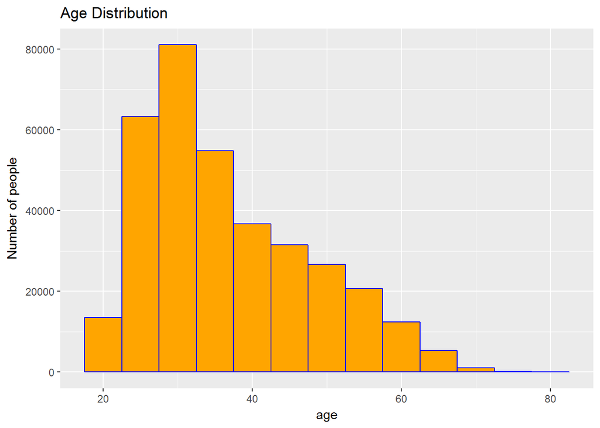

```r
df.trips %>%
  ggplot(aes(x=age)) +
  geom_histogram(binwidth=5,color="blue", fill="orange")+
  ylab("Number of people")+
  ggtitle("Age Distribution")
```

- From the graph, we can see that age of Hubway registered users vary from 20 years old to 70 years old.
- However, it is also noticable that majority our Hubway registered users is in their 30s. Number of Hubway users at 25-30 and 30-35 years old (around 62,000 and 81,000 respectively) is at the highest, followed by number of users at 35-40 years old (55,000).
- There is very small number of users bellow 25 years old or above 70 years old. The number of users decreases for every age group after 30.

### 4.1.2 Gender distribution

- This following table will examine the ditribution of registered Hubway users by gender. It also only considers registered, not casual Hubway users.

```r
df.trips %>%
  group_by(gender)%>%
  summarize(mean_duration=mean(duration,na.rm=TRUE),
            count_trips=length(unique(seq_id))) %>%
  arrange(desc(mean_duration))
```

```
## # A tibble: 3 x 3
##   gender mean_duration count_trips
##    <chr>         <dbl>       <int>
## 1   <NA>      35.58769      472471
## 2 Female      13.69908      268568
## 3   Male      11.82712      825468
```

### 4.1.3 Taking casual user into account

- In the above sections, we only consider registered users, but disregard casual users. As a result, in this section, we want to look at the effect of casual users in the duration of trips.
- Taking the subscription type (registered vs. casual) as a dummy variable, the following linear regression examines how trip duration (dependent variable) depends on subscription type (independent variable).

```r
summary(lm(duration~subsc_type,df.trips))
```

```
##
## Call:
## lm(formula = duration ~ subsc_type, data = df.trips)
##
## Residuals:
##    Min     1Q Median     3Q    Max
##    -35     -9     -5      1 199872
##
## Coefficients:
##                      Estimate Std. Error t value Pr(>|t|)
## (Intercept)           35.5877     0.4238   83.98   <2e-16 ***
## subsc_typeRegistered -23.3010     0.5071  -45.95   <2e-16 ***
## ---
## Signif. codes:  0 '***' 0.001 '**' 0.01 '*' 0.05 '.' 0.1 ' ' 1
##
## Residual standard error: 291.3 on 1566505 degrees of freedom
## Multiple R-squared:  0.001346,   Adjusted R-squared:  0.001345
## F-statistic:  2112 on 1 and 1566505 DF,  p-value: < 2.2e-16
```

- This linear regression result tells us that: keeping all other factors constant, a trip will be 23 minute shorter if the person is subscribed.
- We can interpret this result that a person who is registered is likely to use more commute reason and probably use more and shorter trips.
- However, the R-square value is relatively low, so it only explains 0.13% of the variation; so this is only used as a general guideline.

## 4.2 Trips and Duration

After studying the demographic and characteristics of Hubway users in the previous section, we now want to further examine the characteristics of the trips by those Hubway users. First, we will look at the number of Hubway trips per month to identify the trend, across 3 years and the pattern within a year. We will continue by looking at number of trips and trip duration regarding on each day of the week to see the differences in number of trips/ duration between weekdays and weekend. Lastly, we will examine the trip distribution by duration to see if users usually use Hubway bikes for long trips or short trips.

### 4.2.1 Number of trips per month

- First, we would want to look at Hubway number trips per month, based on from July 2011 to November 2013.
- It should be noted that Hubway stations closed from December to February of 2011 and 2012, and from December to March of 2013.

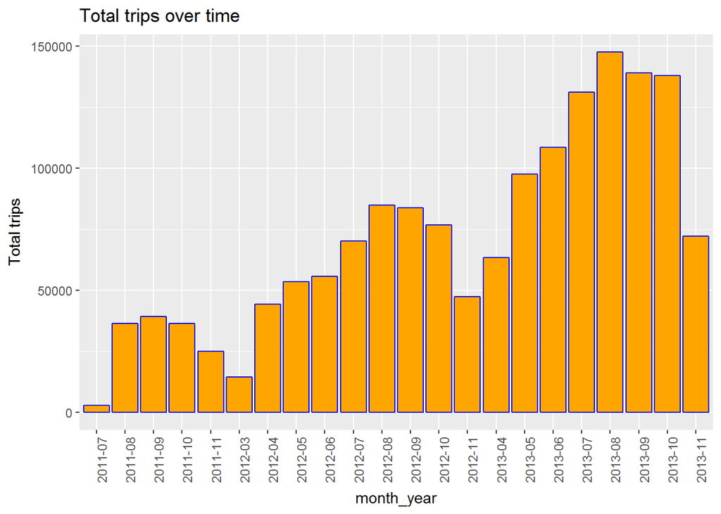

```r
df.trips %>%
  mutate(month_year=format(raw.date,"%Y-%m")) %>%
  ggplot(aes(x=month_year,y=(unique(seq_id))))+
  stat_summary(fun.y=length,geom="bar",fill="orange",color="blue")  +
  #count the length of unique trip id, which is total trips
  theme(axis.text.x=element_text(angle=90,hjust=1))+
  #rotate the x-axis by 90 degree for easier viewing
  ggtitle("Total trips over time") +
  ylab("Total trips")
```

- From the histogram, we can see that the number of trips has grown significantly from 2011 (peaked at around 40,000 trips in September 2011) to 2013 (peaked at nearly 150,000 trips in August 2013)
- There is also some seasonality in total of trips per month within the year. Number of trips starts low in early of the year (March, April), then grows gradually until it peaks in August or September, before it stumbles again in November. This trend makes sense because those low-traffic months are usually winter time and commuting by bikes would be difficult in inclement weather.

### 4.2.2 Number of trips and duration sorting each day of the week

- Next, we would want to investigate the pattern of number of trips and duration in different days of the week. The following table summarize number of trips and average durationg regarding each day.

```r
df.trips %>%
  mutate(weekday=weekdays(raw.date)) %>% #extract weekday from raw date
  group_by(weekday)%>%
  summarize(count_trips=length(unique(seq_id)),
            mean_duration=mean(duration,na.rm=TRUE)) %>%
  arrange(desc(count_trips))
```

```
## # A tibble: 7 x 3
##     weekday count_trips mean_duration
##       <chr>       <int>         <dbl>
## 1 Wednesday      236947      15.82577
## 2  Thursday      232949      15.99679
## 3   Tuesday      230074      15.60927
## 4    Friday      229488      18.90661
## 5    Monday      228645      18.57396
## 6  Saturday      214067      26.11510
## 7    Sunday      194337      25.79301
```

### 4.2.3 Trip distribution by duration

- From the previous section, we know that Hubway users have long bike trips on weekends and short bike trips on weekdays. To continue, we want to compare the total number of long trip to total the number of long trips across 3 years
- We categorize long trip as the ones more than 20 minutes, and short trips as the ones under 20 minutes

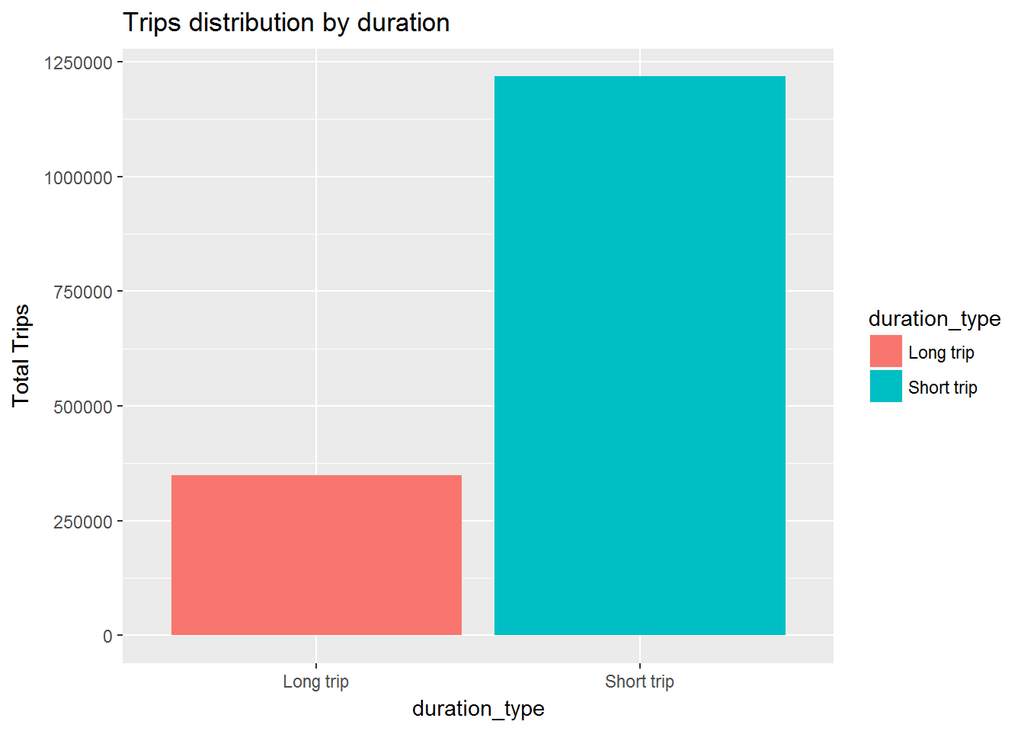

```r
df.trips %>%
  mutate(duration_type=ifelse(df.trips$duration >=20, "Long trip", "Short trip"))%>%
  #if duration is longer than 20 minutes, then "Long trip", otherwise it is short
  ggplot  (aes(x   =duration_type)) +
  geom_bar(aes(fill=duration_type)) +
  ylab("Total Trips")+
  ggtitle("Trips distribution by duration")
```

- From this graph, it is noticable that there are significantly more short trips compare to long trips. This means that Hubway users usually use Hubway bikes for short trips rather than long trips. This is consistent with our findings that Hubway core customers are young professionals who bike to work.

# 5 Network Analysis

Our network analysis aims to understand the network of Hubway through the stations and trips. First, we want to visualize where the stations are located. We will plot the choropleth map on all the station on the Boston map. We also want to include the size of each points to indicate the traffic in each location. In order to do that, we add new column to the `df.stations` by calculating the total incoming trips from the `df.trips` dataset.

```r
df.trips%>%
  group_by(end_statn)%>%
  summarize(incoming_trip=length(end_statn))-> count_trips
  #count number of times that end_station appears, grouped by itself

df.stations%>%
  mutate(incoming_trip=count_trips$incoming_trip)%>%
  #add new column of incoming trips to existing station, because station_id in both tables are arranged from 3->145, making it possible to merge
  {.}->df.stations.graph
```

We then plot the map using the `ggmap` and `ggplot2` libraries

[figure not shown]

```r
qmap(location = "Back Bay, MA", zoom=13, maptype= "terrain" ) +
  geom_point(data=df.stations.graph,aes(x=lng,y=lat,col=municipal, size=incoming_trip))+
  ggtitle("Hubway in Boston")
```

As we can see from the map, Boston areas are the busiest locations for Hubway. The average incoming trips to Boston stations are much higher, and the stations are located densely.

# 6 Conclusion

Based on the analysis of the Hubway system, we conclude the following characteristics of trips and customers of Hubway:

- Hubway is utilized mostly by young professionals during the week to commute to their work
- There is a smaller population group who used them casually, and tend to use them longer